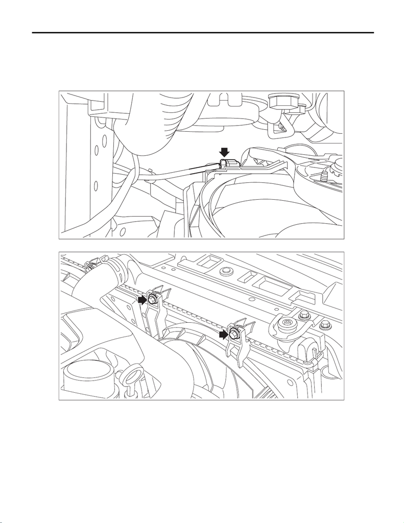

CO(w/o STI)-49

Radiator Sub Fan and Fan Motor

COOLING

10.Radiator Sub Fan and Fan Motor

A: REMOVAL

1) Disconnect the ground terminal from battery sensor. <Ref. to NT-5, BATTERY, NOTE, Note.>

2) Remove the air intake duct. <Ref. to IN(w/o STI)-22, REMOVAL, Air Intake Duct.>

3) Disconnect the connector from the sub fan motor.

4) Remove the bolts which secure the radiator sub fan motor assembly onto the radiator.

5) Remove the radiator sub fan motor assembly from the vehicle.

B: INSTALLATION

Install in the reverse order of removal.

CAUTION:

Confirm that the radiator hose is securely connected.

Tightening torque:

7.5 N·m (0.8 kgf-m, 5.5 ft-lb)

CO-03221

CO-03363

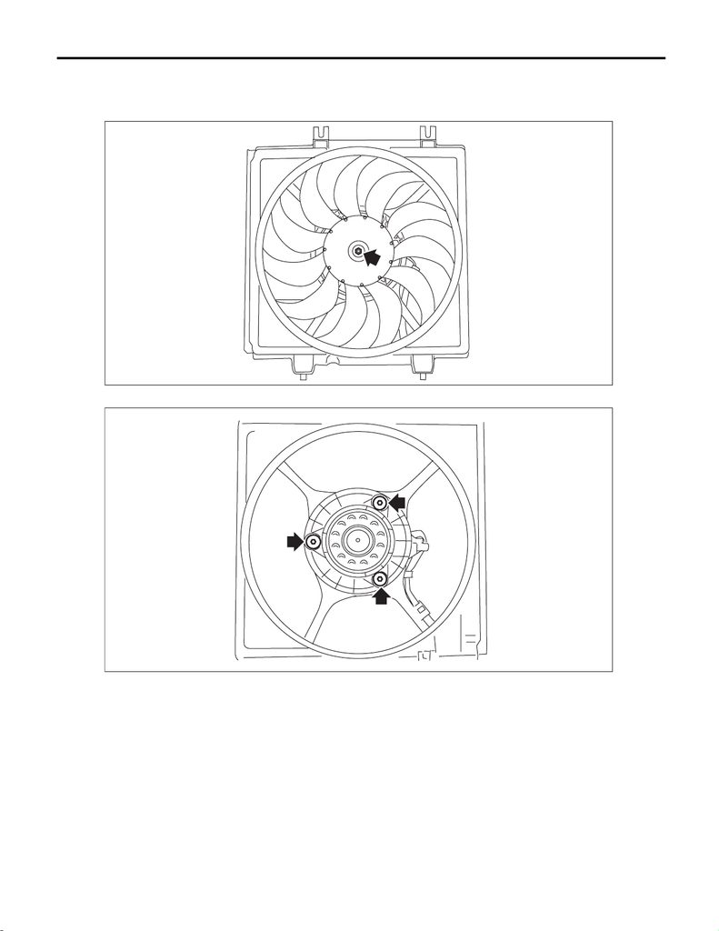

CO(w/o STI)-50

Radiator Sub Fan and Fan Motor

COOLING

C: DISASSEMBLY

1) Remove the clip which holds the sub fan motor connector onto the radiator sub fan shroud.

2) Disconnect the radiator sub fan from the sub fan motor.

3) Disconnect the sub fan motor from the radiator sub fan shroud.

CO-03079

CO-02871

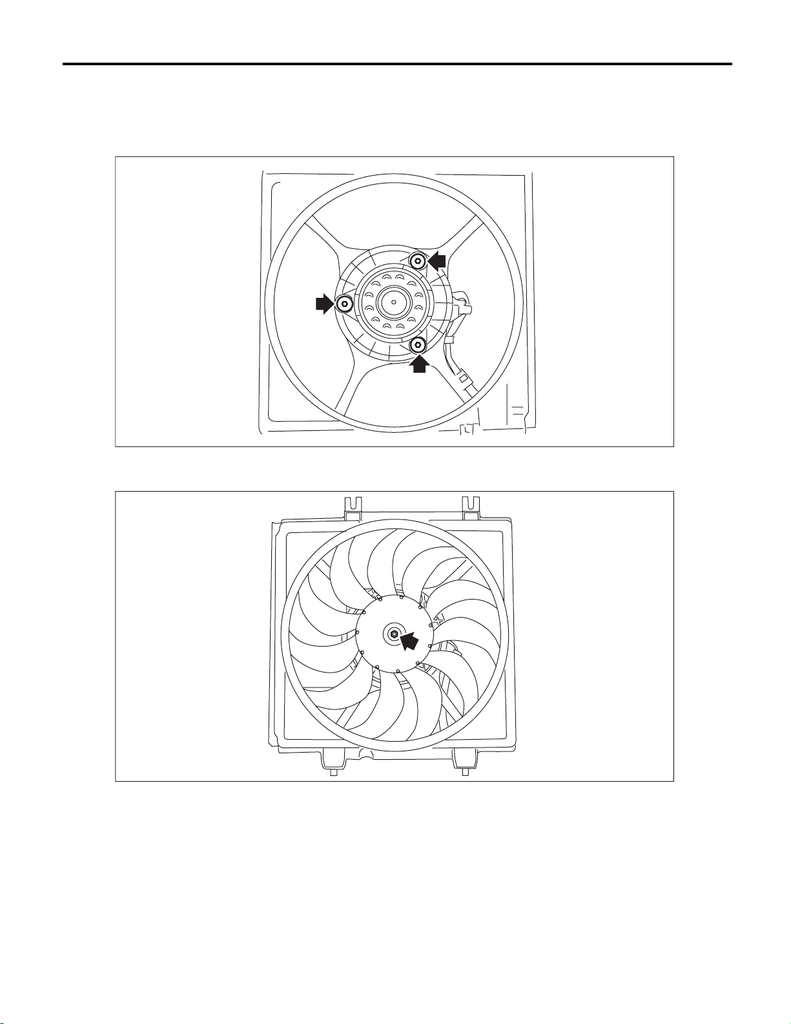

CO(w/o STI)-51

Radiator Sub Fan and Fan Motor

COOLING

D: ASSEMBLY

Assemble in the reverse order of disassembly.

Tightening torque:

4.41 N·m (0.45 kgf-m, 3.25 ft-lb)

Tightening torque:

3.4 N·m (0.3 kgf-m, 2.5 ft-lb)

E: INSPECTION

Check that the radiator sub fan, radiator sub fan shroud and sub fan motor do not have deformation, cracks

or damage.

CO-02871

CO-03079